# colon 데이터 rx 변수의 처리

202116927 오준석

2024-05-22

```r
library(survival)
library(ggplot2)
library(dplyr)
library(gridExtra)
str(colon)
```

```
## 'data.frame':    1858 obs. of  16 variables:
##  $ id      : num  1 1 2 2 3 3 4 4 5 5 ...
##  $ study   : num  1 1 1 1 1 1 1 1 1 1 ...
##  $ rx      : Factor w/ 3 levels "Obs","Lev","Lev+5FU": 3 3 3 3 1 1 3 3 1 1 ...
##  $ sex     : num  1 1 1 1 0 0 0 0 1 1 ...
##  $ age     : num  43 43 63 63 71 71 66 66 69 69 ...
##  $ obstruct: num  0 0 0 0 0 0 1 1 0 0 ...
##  $ perfor  : num  0 0 0 0 0 0 0 0 0 0 ...
##  $ adhere  : num  0 0 0 0 1 1 0 0 0 0 ...
##  $ nodes   : num  5 5 1 1 7 7 6 6 22 22 ...
##  $ status  : num  1 1 0 0 1 1 1 1 1 1 ...
##  $ differ  : num  2 2 2 2 2 2 2 2 2 2 ...
##  $ extent  : num  3 3 3 3 2 2 3 3 3 3 ...
##  $ surg    : num  0 0 0 0 0 0 1 1 1 1 ...
##  $ node4   : num  1 1 0 0 1 1 1 1 1 1 ...
##  $ time    : num  1521 968 3087 3087 963 ...
##  $ etype   : num  2 1 2 1 2 1 2 1 2 1 ...
```

```r
?colon
```

```
## httpd 도움말 서버를 시작합니다 ...
```

```
##  완료
```

colon 데이터에는 16개의 변수가 있는 것을 알 수 있음 각각의 변수의 의미를 살펴보았을 때 id, study는 다른 변수와 상관관계가 없고, time과 etype은 결과를 알려주는 변수이므로 이를 제외하고 변수 간의 상관관계를 확인함

```r
clean_colon <- colon[c(TRUE, FALSE), ]
```

```r
table(is.na(clean_colon))
```

```
##
## FALSE  TRUE
## 14823    41
```

데이터에 결측치가 있는 것이 확인되었으므로 이를 제거함

```r
clean_colon <- na.omit(clean_colon)
table(is.na(clean_colon))
```

```
##
## FALSE
## 14208
```

ggplot 함수를 이용해 rx와 변수들이 갖는 상관관계를 시각화

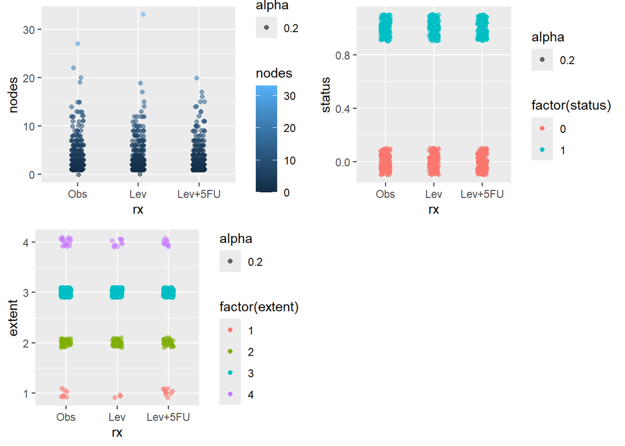

```r
p1 <- clean_colon%>%ggplot(aes(rx, nodes))+geom_jitter(aes(col=nodes, alpha=0.2), height=0.1, width=0.1)
p2 <- clean_colon%>%ggplot(aes(rx, status))+geom_jitter(aes(col=factor(status), alpha=0.2), height=0.1, width=0.1)
p3 <- clean_colon%>%ggplot(aes(rx, extent))+geom_jitter(aes(col=factor(extent), alpha=0.2), height=0.1, width=0.1)
grid.arrange(p1, p2, p3, ncol=2, nrow=2)
```

이것만을 이용했을 때 각각의 변수들 간의 상관관계를 명확히 파악할 수 없으므로 glm 함수를 이용하여 rx와 status 간의 상관관계를 파악함

```r
m=glm(status~rx, data=clean_colon, family=binomial)
summary(m)
```

```
##
## Call:
## glm(formula = status ~ rx, family = binomial, data = clean_colon)
##
## Coefficients:
##             Estimate Std. Error z value Pr(>|z|)
## (Intercept)   0.1511     0.1148   1.316  0.18827
## rxLev        -0.1239     0.1637  -0.757  0.44915
## rxLev+5FU    -0.5364     0.1660  -3.232  0.00123 **
## ---
## Signif. codes:  0 '***' 0.001 '**' 0.01 '*' 0.05 '.' 0.1 ' ' 1
##
## (Dispersion parameter for binomial family taken to be 1)
##
##     Null deviance: 1230.1  on 887  degrees of freedom
## Residual deviance: 1218.7  on 885  degrees of freedom
## AIC: 1224.7
##
## Number of Fisher Scoring iterations: 4
```

이때 rx가 rxLev와 rxLev+5FU 두 개의 변수로 나뉘는 것을 볼 수 있음.

chatGPT를 이용하여 원핫 코드로 rx를 나타내는 함수를 만듦. charGPT가 제공한 함수에는 두 가지 변수를 추가하는 과정이 없으므로 이를 추가함.

```r
library(ModelMatrixModel)
rx_onehot <- model.matrix(~ rx - 1, data = clean_colon)
clean_colon_onehot <- cbind(clean_colon, rx_onehot)
colnames(clean_colon_onehot)
```

```
##  [1] "id"        "study"     "rx"        "sex"       "age"       "obstruct"
##  [7] "perfor"    "adhere"    "nodes"     "status"    "differ"    "extent"
## [13] "surg"      "node4"     "time"      "etype"     "rxObs"     "rxLev"
## [19] "rxLev+5FU"
```

```r
clean_colon_onehot$rxLev5FU <- clean_colon_onehot$"rxLev+5FU"
m <- glm(status ~ rxLev + rxLev5FU, data = clean_colon_onehot, family = binomial)
summary(m)
```

```
##
## Call:
## glm(formula = status ~ rxLev + rxLev5FU, family = binomial, data = clean_colon_onehot)
##
## Coefficients:
##             Estimate Std. Error z value Pr(>|z|)
## (Intercept)   0.1511     0.1148   1.316  0.18827
## rxLev        -0.1239     0.1637  -0.757  0.44915
## rxLev5FU     -0.5364     0.1660  -3.232  0.00123 **
## ---
## Signif. codes:  0 '***' 0.001 '**' 0.01 '*' 0.05 '.' 0.1 ' ' 1
##
## (Dispersion parameter for binomial family taken to be 1)
##
##     Null deviance: 1230.1  on 887  degrees of freedom
## Residual deviance: 1218.7  on 885  degrees of freedom
## AIC: 1224.7
##
## Number of Fisher Scoring iterations: 4
```

이때 원핫 인코딩을 사용하였음. rx는 세 개의 변수를 포함하는 범주형 변수인데, 일반적인 선형 모델에서는 세 가지 변수를 포함하는 범주형 변수를 사용할 수 없기 때문에 두 개로 분할된 rx를 따로 이진법으로 나타내어 선형화 가능한 형태로 만드는 것임. 이러한 과정을 통해 rx에서 분할된 각각의 변수와 status 사이의 상관관계를 모델링할 수 있게 됨.